# 1 About

## 1.1 Contributions

Please note that authorship is alphabetical. Contributions are listed below - see [github](https://github.com/CfSOtago/waterQual/commits/master) for details and who to blame for what :-).

Ben Anderson (b.anderson@soton.ac.uk `@dataknut`)

## 1.2 Code

- Repo: https://github.com/CfSOtago/waterQual/

## 1.3 Citation

If you wish to refer to any of the material from this report please cite as:

- Anderson, B., (2019) Water Quality in New Zealand: Exploring “official” data , University of Southampton: Southampton, UK.

Report circulation:

- Public.

Report purpose:

- to explore `official` New Zealand Water Quality data

This work has received funding from the European Union’s Horizon 2020 research and innovation programme under the [Marie Skłodowska-Curie](http://ec.europa.eu/research/mariecurieactions/index_en.htm) grant agreement No 700386 ([SPATIALEC](http://www.energy.soton.ac.uk/tag/spatialec/)).

This work is (c) 2019 the University of Southampton.

# 2 Introduction

## 2.1 ‘Trend’ data

Data source: https://data.mfe.govt.nz/data/category/fresh-water/

Data file: mfe-river-water-quality-trends-20082017-19982017-and-19902017-CSV/river-water-quality-trends-20082017-19982017-and-1990-2017-raw-data.csv

```r
df <- paste0(dPath, dataFile)

wqdt <- data.table::fread(df)
```

Overall there are:

- 1107 sites

This isn’t really trend or raw data - it is a single record per site with indicator of change via a trend slope coefficient or a single % change value. We were looking for the data used to create the time-series plots in (for example) https://www.lawa.org.nz/explore-data/otago-region/river-quality/manuherikia-river/manuherikia-at-ophir/

There are also data quality & missing data issues (see Statistical Annex). It’s noticeable for example that, irrespective of the indicator, over half of stations were thought to have insufficient data to determine trend direction. This was true of 70% of stations for [ECOLI](https://www.stats.govt.nz/indicators/river-water-quality-escherichia-coli) and 78% for the Macroinvertebrate Community Index ([MCI](https://www.stats.govt.nz/indicators/river-water-quality-macroinvertebrate-community-index)).

```r
tq <- table(wqdt$TrendCategory, wqdt$npID)

kableExtra::kable(addmargins(tq), caption = "Trend category counts") %>% kable_styling()
```

Table 2.1: Trend category counts

|  | CLAR | DRP | ECOLI | MCI | NH4N | NO3N | TN | TP | TURB | Sum |
| --- | --- | --- | --- | --- | --- | --- | --- | --- | --- | --- |
| Decreasing | 82 | 355 | 167 | 132 | 428 | 318 | 204 | 415 | 137 | 2238 |
| Increasing | 259 | 245 | 118 | 79 | 79 | 266 | 211 | 91 | 173 | 1521 |
| Insufficient Data | 426 | 630 | 642 | 764 | 713 | 593 | 499 | 578 | 567 | 5412 |
| Sum | 767 | 1230 | 927 | 975 | 1220 | 1177 | 914 | 1084 | 877 | 9171 |

```r
kableExtra::kable(100 * prop.table(tq, 2), digits = 2, caption = "Trend category %") %>%
    kable_styling()
```

Table 2.1: Trend category %

|  | CLAR | DRP | ECOLI | MCI | NH4N | NO3N | TN | TP | TURB |
| --- | --- | --- | --- | --- | --- | --- | --- | --- | --- |
| Decreasing | 10.69 | 28.86 | 18.02 | 13.54 | 35.08 | 27.02 | 22.32 | 38.28 | 15.62 |
| Increasing | 33.77 | 19.92 | 12.73 | 8.10 | 6.48 | 22.60 | 23.09 | 8.39 | 19.73 |
| Insufficient Data | 55.54 | 51.22 | 69.26 | 78.36 | 58.44 | 50.38 | 54.60 | 53.32 | 64.65 |

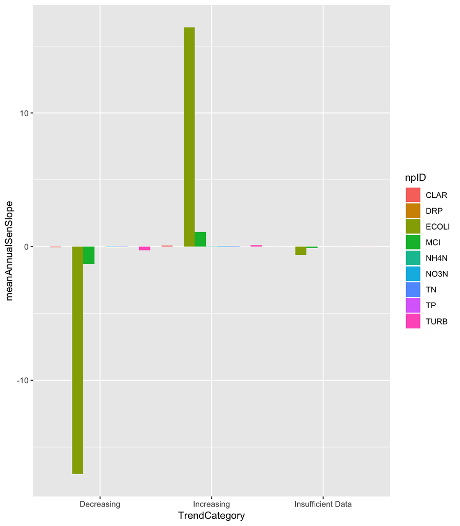

Figure 2.1: Test data values by indicator

```r
plotDT <- wqdt[, .(meanAnnualSenSlope = mean(AnnualSenSlope, na.rm = TRUE)),
    keyby = .(npID, TrendCategory)]
ggplot2::ggplot(plotDT, aes(x = TrendCategory, y = meanAnnualSenSlope, group = npID,
    fill = npID)) + geom_col(position = "dodge")
```

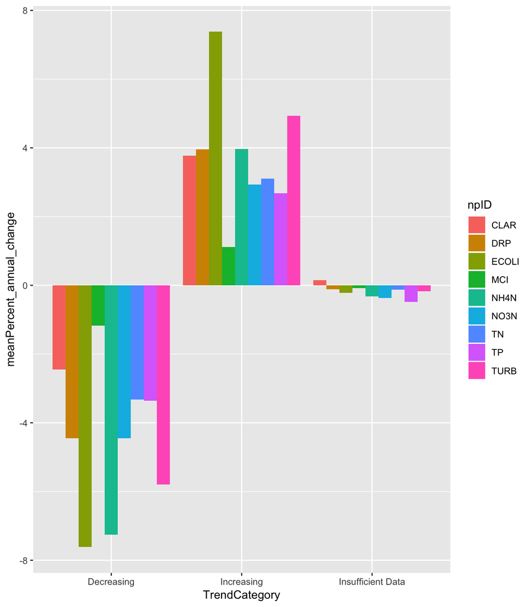

Figure 2.2: Test data values by indicator

```r
plotDT <- wqdt[, .(meanPercent_annual_change = mean(Percent_annual_change, na.rm = TRUE)),
    keyby = .(npID, TrendCategory)]
ggplot2::ggplot(plotDT, aes(x = TrendCategory, y = meanPercent_annual_change,
    group = npID, fill = npID)) + geom_col(position = "dodge")
```

Now try to plot individual trends. This is nasty…

Ideally we want to sort by value within pollutant and ‘fade out’ the ones with insufficient data. Colour coding needs to be careful - for some such as MCI an increase is ‘good’.

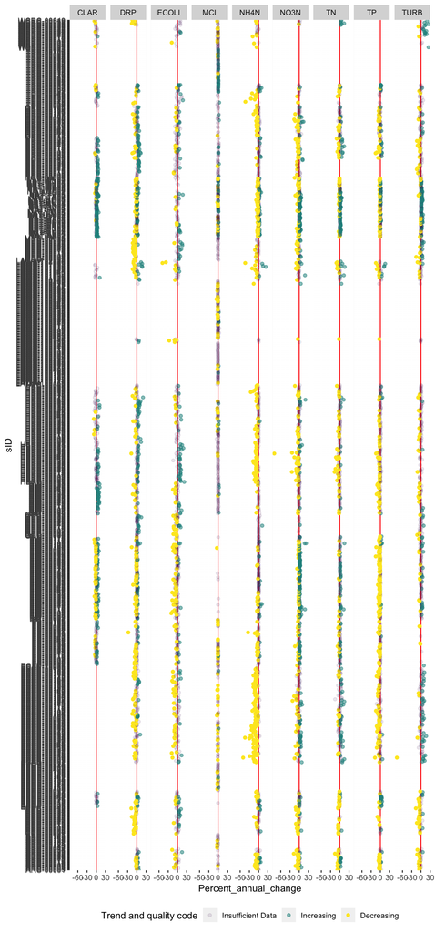

Figure 2.3: Site level trend plots

```r
p <- ggplot2::ggplot(wqdt, aes(y = sID,
                               x = Percent_annual_change,
                               alpha = forcats::fct_rev(TrendCategory), # reverse so lightest alpha == least data
                               colour = forcats::fct_rev(TrendCategory)
                               )
                     ) +
  geom_vline(xintercept = 0, colour = "red") +
  geom_point() +
  guides(alpha = guide_legend(title = "Trend and quality code")
         ) +
  guides(colour = guide_legend(title = "Trend and quality code")
         ) +
  scale_color_viridis(discrete = TRUE) +
  theme(legend.position = "bottom") +
  facet_grid(. ~ npID)

p
```

# 3 Statistical Annex

## 3.1 Trend ‘raw’ data

```r
skimr::skim(wqdt)
```

```
## Skim summary statistics
##  n obs: 9171
##  n variables: 42
##
## ── Variable type:character ───────────────────────────────────────────────────────────────────────
##        variable missing complete    n min max empty n_unique
##    AnalysisNote       0     9171 9171   2  52     0        9
##         climate       0     9171 9171   2   2     0        6
##   DirectionConf       0     9171 9171   6  22     0       10
##       landcover       0     9171 9171   1   2     0        8
##            npID       0     9171 9171   2   5     0        9
##          Season       0     9171 9171   5   8     0        3
##             sID       0     9171 9171   8  11     0     1107
##      src_of_flw       0     9171 9171   1   2     0        5
##   TrendCategory       0     9171 9171  10  17     0        3
##  TrendDirection       0     9171 9171  10  13     0        4
##
## ── Variable type:integer ─────────────────────────────────────────────────────────────────────────
##         variable missing complete    n       mean         sd     p0
##                D     123     9048 9171    3834.87    8388.81     15
##  no_censorlevels       0     9171 9171       0.64       1.05      0
##             nObs       0     9171 9171     119.47      89.47      5
##          nzreach       0     9171 9171 8353123.65 4569119.66  1e+06
##        nzsegment       0     9171 9171 8463644.58 4596199.64  1e+06
##           Period       0     9171 9171      13.97       6.03     10
##                S     123     9048 9171    -176.53    1953.93 -24882
##                X       0     9171 9171    1947.94    1673.87      1
##      p25     p50        p75        p100     hist
##      463     703 4186       56280       ▇▁▁▁▁▁▁▁
##        0       0    1          21       ▇▁▁▁▁▁▁▁
##       40     117  120         336       ▆▁▇▁▁▃▁▁
##    3e+06   8e+06    1.3e+07     1.5e+07 ▃▇▂▆▂▂▆▆
##  3149001 8206040    1.3e+07     1.5e+07 ▃▇▂▃▅▂▇▆
##       10      10   20          28       ▇▁▁▁▃▁▁▁
##     -133     -14   50       26493       ▁▁▁▇▁▁▁▁
##      473    1447 3290.5      5583       ▇▃▃▂▂▂▂▂
##
## ── Variable type:logical ─────────────────────────────────────────────────────────────────────────
##  variable missing complete    n mean                       count
##  Seasonal       0     9171 9171 0.58 TRU: 5278, FAL: 3893, NA: 0
```

[output cut: 59 more lines]

```
##  ▂▂▂▃▃▇▃▁
##  ▅▅▅▅▇▇▆▂
##  ▇▂▂▁▁▁▁▁
##  ▁▁▁▁▁▃▇▁
##  ▅▂▁▂▂▂▂▇
##  ▃▁▁▁▁▁▂▇
##  ▇▂▂▂▂▂▂▇
##  ▇▁▁▁▁▁▁▁
##  ▂▃▃▅▆▇▇▅
##  ▅▂▁▁▁▂▂▇
##  ▇▁▁▁▁▁▁▁
##  ▁▁▃▇▆▂▁▁
##  ▁▁▇▁▁▁▁▁
##  ▇▁▁▁▁▁▁▁
##  ▁▁▃▇▂▁▁▁
```

```r
tn <- wqdt[!is.na(AnalysisNote) & AnalysisNote != "ok", .(sID, npID, AnalysisNote)]

kableExtra::kable(tn, caption = "Analysis notes")
```

Table 3.1: Analysis notes

| sID | npID | AnalysisNote |
| --- | --- | --- |
| ARC-00001 | NH4N | WARNING: Sen slope influenced by censored values |
| ARC-00004 | DRP | WARNING: Sen slope based on tied non-censored values |
| ARC-00006 | TP | WARNING: Sen slope based on tied non-censored values |
| ARC-00011 | DRP | WARNING: Sen slope based on tied non-censored values |
| ARC-00015 | DRP | WARNING: Sen slope based on tied non-censored values |
| ARC-00016 | DRP | WARNING: Sen slope based on tied non-censored values |
| ARC-00017 | DRP | WARNING: Sen slope influenced by censored values |
| ARC-00017 | TURB | WARNING: Sen slope based on tied non-censored values |
| ARC-00019 | TP | WARNING: Sen slope based on tied non-censored values |
| ARC-00024 | DRP | WARNING: Sen slope influenced by censored values |
| ARC-00024 | NO3N | WARNING: Sen slope based on tied non-censored values |
| ARC-00026 | DRP | WARNING: Sen slope based on tied non-censored values |
| ARC-00027 | ECOLI | WARNING: Sen slope influenced by censored values |
| ARC-00027 | NH4N | WARNING: Sen slope influenced by censored values |
| ARC-00030 | NH4N | WARNING: Sen slope influenced by censored values |
| ARC-00030 | NO3N | WARNING: Sen slope based on tied non-censored values |
| ARC-00031 | DRP | WARNING: Sen slope influenced by censored values |
| ARC-00034 | DRP | WARNING: Sen slope based on tied non-censored values |
| CCC-00001 | NH4N | WARNING: Sen slope influenced by censored values |
| CCC-00001 | TP | WARNING: Sen slope influenced by censored values |
| CCC-00002 | ECOLI | WARNING: Sen slope based on tied non-censored values |
| CCC-00002 | TP | WARNING: Sen slope influenced by censored values |
| CCC-00003 | NH4N | WARNING: Sen slope influenced by censored values |
| CCC-00003 | TP | WARNING: Sen slope influenced by censored values |
| CCC-00004 | NH4N | WARNING: Sen slope influenced by censored values |
| CCC-00005 | TP | WARNING: Sen slope influenced by censored values |
| CCC-00007 | TP | WARNING: Sen slope influenced by censored values |
| CCC-00008 | ECOLI | WARNING: Sen slope based on tied non-censored values |
| CCC-00009 | TP | WARNING: Sen slope influenced by censored values |
| CCC-00013 | TURB | WARNING: Sen slope based on tied non-censored values |

[output cut: 1894 more lines]

# 4 Runtime

Report generated using knitr in [RStudio](http://www.rstudio.com) with R version 3.5.2 (2018-12-20) running on x86_64-apple-darwin15.6.0 (Darwin Kernel Version 17.7.0: Wed Apr 24 21:17:24 PDT 2019; root:xnu-4570.71.45~1/RELEASE_X86_64).

```r
t <- proc.time() - startTime

elapsed <- t[[3]]
```

Analysis completed in 21.141 seconds ( 0.35 minutes).

# 5 References